# Spring 2025 Data Science Project: Berlin Marathon Analysis

## Team Members and Contributions

Ben Talesnik & Zach Hiner

### Contributions:

For each team member, list their contributions across the following categories:

- A: Project idea
  - We both contributed to the project idea due to our interest in the sport of running. We are both fanscinated in marathon running and wanted to analyze the data to see how the sport has evolved over time.
- B: Dataset Curation and Preprocessing
  - Ben was responsible for curating the dataset and preprocessing the data. He also created the initial data exploration and summary statistics.
- C: Data Exploration and Summary Statistics
  - Zach was responsible for the gender performance difference, year-over-year performance trends, and a pace analysis. He also created the visualization and result analysis.
- D: ML Algorithm Design/Development
  - Ben was responsible for the linear regression model and the forecast analysis. He also created the 5th percentile finish time analysis.
- E: ML Algorithm Training and Test Data Analysis
  - Zach helped code the linear regression model and the forecast analysis. He was able to determine the best fit line for the data and the forecast for the future.
- F: Visualization, Result Analysis, Conclusion
  - Both of us worked to create the visualization and result analysis. We both worked to create the conclusion and write the tutorial report.
- G: Final Tutorial Report Creation
  - We both met to write the tutorial report and finalize the project.
- H: Additional
  - We also both worked together to ensure all of our progress was stored in the GitHub repository.

## 1. Introduction

This project analyzes Berlin Marathon results from 1999 to 2019, one of the world's most prestigious marathon events. Through this analysis, we aim to:

1. Has the average time to finish the marathon decreased over time?
2. How has the average time to finish the marathon changed over time for different genders?
3. How has the average time to finish the marathon changed over time for different countries?

Understanding these patterns is important because it can help us understand how the sport of marathon running has evolved over time. It demonstrates the impact of technology, training, and other factors on marathon performance. With the introduction of carbon plated shoes, new fitness tests, and other factors, it is important to understand how these changes have affected the sport.

## 2. Data Curation and Preprocessing

### Data Source

Marathon finisher results from the Berlin marathon between 1999 and 2019. Miller, Andrew, Marathon Results, (2021), GitHub Repository,  
https://github.com/AndrewMillerOnline/marathon-results

### Initial Data Overview

The dataset contains information about the runners, their times, and other details from a few of the world's most prestigious marathons. We have chosen to focus on the Berlin Marathon due to the completeness of the dataset. The dataset includes information including:

- Place
- Name
- Nationality
- Club
- Time
- Gender
- Splits for 5k, 10k, 15k, 20k, 25k, 30k, 35k, 40k
- Year

This dataset is useful for our analysis because it contains a large amount of information about the runners, including their times, gender, nationality, and club.

```python
# Importing necessary libraries
import pandas as pd
import numpy as np
import matplotlib.pyplot as plt
import seaborn as sns
from pathlib import Path
from scipy import stats
from sklearn.preprocessing import OneHotEncoder
from sklearn.linear_model import LinearRegression
from sklearn.ensemble import RandomForestRegressor
from sklearn.model_selection import RandomizedSearchCV
from sklearn.model_selection import train_test_split
from sklearn.metrics import mean_squared_error, r2_score

# Set style for all visualizations
sns.set_palette('husl')
plt.style.use("seaborn-v0_8")

# Configure pandas display options
pd.set_option('display.max_columns', None)
pd.set_option('display.max_rows', 10)
```

### Data Loading and Preprocessing

The dataset overall is very clean and does not require much preprocessing. With the initial import, we're focusing on ensuring the current years are imported (1999-2019). With each year added to the dataframe, a year column is created to keep track of the year of the marathon.

```python
START_YEAR = 1999
END_YEAR = 2019

# Create a list of dataframes
dfs = []
for year in range(START_YEAR, END_YEAR + 1):
    df = pd.read_csv(f'./data/results-{year}.csv')
    df['year'] = year
    dfs.append(df)

# Concatenate all dataframes
results = pd.concat(dfs, ignore_index=True)

# Drop rows with missing values, even though we know there are none
results = results.dropna()

display(results)
```

|  | place_overall | first_name | last_name | nationality | club | time_full | gender | split_5k | split_10k | split_15k | split_20k | time_half | split_25k | split_30k | split_35k | split_40k | Race | year |
| --- | --- | --- | --- | --- | --- | --- | --- | --- | --- | --- | --- | --- | --- | --- | --- | --- | --- | --- |
| 0 | 1 | Josephat | Kiprono | KEN | Kenia | 02:06:44 | M | 00:15:09 | 00:30:21 | 00:45:25 | 01:00:34 | 01:03:54 | 01:14:54 | 01:30:10 | 01:45:05 | 02:00:08 | Berlin | 1999 |
| 1 | 2 | Takayuki | Inubushi | JPN | Japan | 02:06:57 | M | 00:15:09 | 00:30:21 | 00:45:27 | 01:00:36 | 01:03:54 | 01:14:56 | 01:30:18 | 01:45:21 | 02:00:18 | Berlin | 1999 |
| 2 | 3 | Samson | Kandie | KEN | Kenia | 02:08:31 | M | 00:15:10 | 00:30:21 | 00:45:27 | 01:00:35 | 01:03:54 | 01:14:55 | 01:30:18 | 01:45:59 | 02:01:41 | Berlin | 1999 |
| 3 | 4 | Hicham | Chatt | MAR | Marokko | 02:09:56 | M | 00:15:11 | 00:30:23 | 00:45:27 | 01:00:36 | 01:03:55 | 01:14:56 | 01:30:24 | 01:46:14 | 02:02:52 | Berlin | 1999 |
| 4 | 5 | Henry | Cherono | KEN | Kenia | 02:10:37 | M | 00:15:10 | 00:30:21 | 00:00:00 | 01:00:35 | 01:03:55 | 01:14:55 | 01:30:18 | 01:46:14 | 02:02:58 | Berlin | 1999 |
| ... | ... | ... | ... | ... | ... | ... | ... | ... | ... | ... | ... | ... | ... | ... | ... | ... | ... | ... |
| 678702 | 30739 | Wolfgang | Biedermann | GER | SC . LT SAD ,Spiridon | 07:12:30 | M | 00:39:11 | 01:26:52 | 02:15:21 | 03:09:25 | 03:22:13 | 04:06:45 | 05:04:06 | 05:56:57 | 06:49:33 | Berlin | 2019 |
| 678705 | 13243 | Elvira | Ernst | GER | 261 Fearless | 07:14:44 | W | 00:46:10 | 01:34:15 | 02:23:21 | 03:12:21 | 03:22:44 | 04:02:34 | 04:56:52 | 05:50:44 | 06:48:44 | Berlin | 2019 |
| 678706 | 30740 | Gert | Kleinschmidt | GER | Dessauer SV 97 | 07:15:28 | M | 00:49:05 | 01:42:38 | 02:38:02 | 03:27:30 | 03:37:40 | 04:16:57 | 05:09:49 | 06:01:58 | 06:54:25 | Berlin | 2019 |
| 678709 | 30741 | Oscar | Martinez | USA | BRIDERUNNERS | 07:19:28 | M | 00:37:26 | 01:18:14 | 02:05:06 | 02:59:24 | 03:10:51 | 03:56:15 | 04:58:07 | 06:01:29 | 06:56:38 | Berlin | 2019 |
| 678710 | 30742 | Dietmar | John | GER | Bayerische Laufzeitung-Der Che | 07:26:09 | M | 00:42:11 | 01:29:17 | 02:21:20 | 03:13:21 | 03:24:52 | 04:09:27 | 05:07:35 | 06:04:09 | 07:01:16 | Berlin | 2019 |

290390 rows × 18 columns

Now we need to convert the time column to a more usable format. We need to go through each of the time columns and convert them to a datetime object. Each time is converted to minutes for easier analysis.

```python
# Convert time columns to datetime
time_columns = ['time_full', 'split_5k', 'split_10k', 'split_15k', 'split_20k',
                'time_half', 'split_25k', 'split_30k', 'split_35k', 'split_40k']

for col in time_columns:
    dt = pd.to_datetime(results[col], format='%H:%M:%S')
    results[f'{col}_minutes'] = (
        dt.dt.hour * 60 +
        dt.dt.minute +
        dt.dt.second / 60
    )

# Remove any rows where the time is under 100 minutes
results = results[results['time_full_minutes'] >= 100]
```

## 3. Exploratory Data Analysis

In this section, we'll explore key characteristics of our dataset through summary statistics and visualizations.

### Summary Statistics

```python
# Basic information about the dataset
display("Dataset Shape:", results.shape)
display("Columns:", results.columns.tolist())
display("Data Types:", results.dtypes)
display("Missing Values:", results.isnull().sum())
display("Mean:", results['time_full_minutes'].mean())
display("Median:", results['time_full_minutes'].median())
```

```
'Dataset Shape:'
```

```
(290389, 28)
```

```
'Columns:'
```

```
['place_overall',
 'first_name',
 'last_name',
 'nationality',
 'club',
 'time_full',
 'gender',
 'split_5k',
 'split_10k',
 'split_15k',
 'split_20k',
 'time_half',
 'split_25k',
 'split_30k',
 'split_35k',
 'split_40k',
 'Race',
 'year',
 'time_full_minutes',
 'split_5k_minutes',
 'split_10k_minutes',
 'split_15k_minutes',
 'split_20k_minutes',
 'time_half_minutes',
 'split_25k_minutes',
 'split_30k_minutes',
 'split_35k_minutes',
 'split_40k_minutes']
```

```
'Data Types:'
```

```
place_overall          int64
first_name            object
last_name             object
nationality           object
club                  object
                      ...
time_half_minutes    float64
split_25k_minutes    float64
split_30k_minutes    float64
split_35k_minutes    float64
split_40k_minutes    float64
Length: 28, dtype: object
```

```
'Missing Values:'
```

```
place_overall        0
first_name           0
last_name            0
nationality          0
club                 0
                    ..
time_half_minutes    0
split_25k_minutes    0
split_30k_minutes    0
split_35k_minutes    0
split_40k_minutes    0
Length: 28, dtype: int64
```

```
'Mean:'
```

```
np.float64(241.469336476244)
```

```
'Median:'
```

```
np.float64(237.23333333333332)
```

We have chosen to look at a few different aspects of the dataset. We will be looking at the distribution of finish times, the gender distribution, and the correlation between splits.

With further statistical analysis, we will look at the gender performance difference, year-over-year performance trends, and a pace analysis.

### Distribution of Finish Times

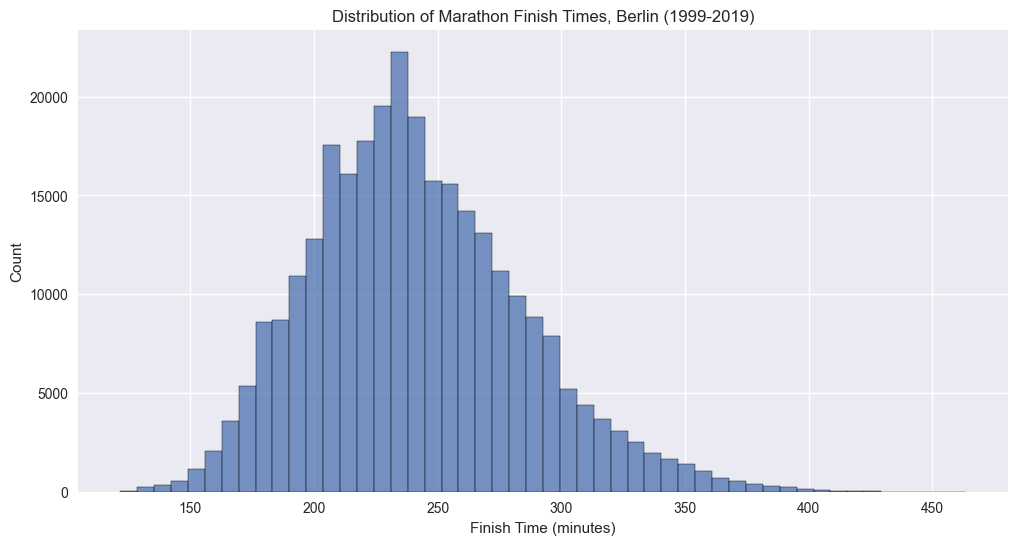

```python
plt.figure(figsize=(12, 6))
sns.histplot(data=results, x='time_full_minutes', bins=50)
plt.title('Distribution of Marathon Finish Times, Berlin (1999-2019)')
plt.xlabel('Finish Time (minutes)')
plt.ylabel('Count')
plt.show()
```

### Distribution of Genders

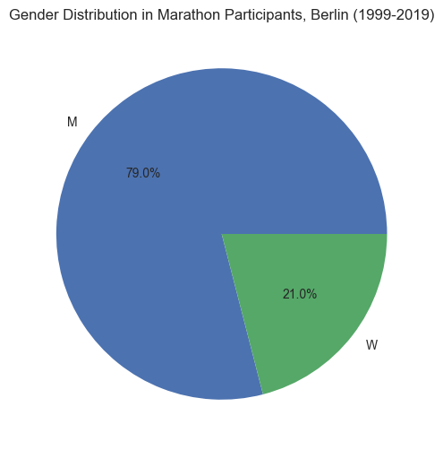

```python
gender_counts = results['gender'].value_counts()

plt.figure(figsize=(8, 6))
plt.pie(gender_counts, labels=gender_counts.index, autopct='%1.1f%%')
plt.title('Gender Distribution in Marathon Participants, Berlin (1999-2019)')
plt.show()
```

The gender distribution shows that there are way more male participants than female participants. Between 1999 and 2019, 79% of participants were male while only 21% were female.

### Correlation Between Splits

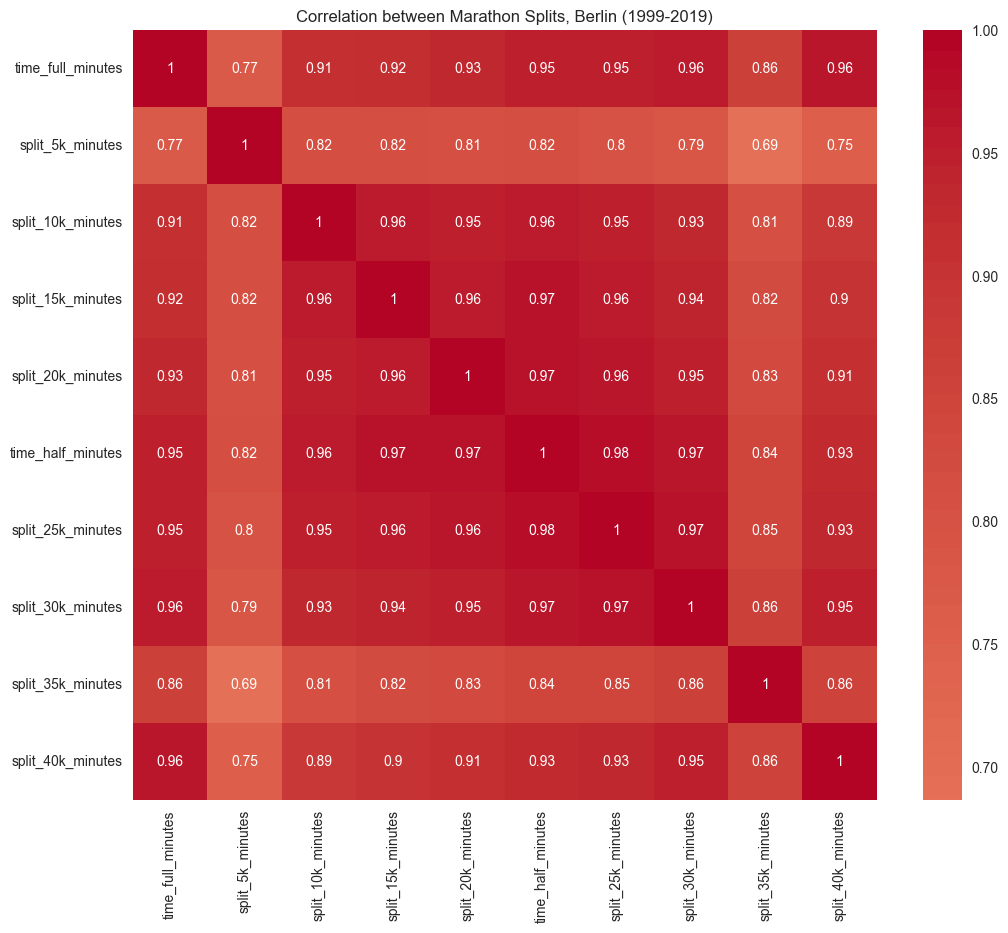

```python
split_columns = [col for col in results.columns if 'minutes' in col]
correlation_matrix = results[split_columns].corr()

plt.figure(figsize=(12, 10))
sns.heatmap(correlation_matrix, annot=True, cmap='coolwarm', center=0)
plt.title('Correlation between Marathon Splits, Berlin (1999-2019)')
plt.show()
```

### Statistical Analysis 1: Gender Performance Difference

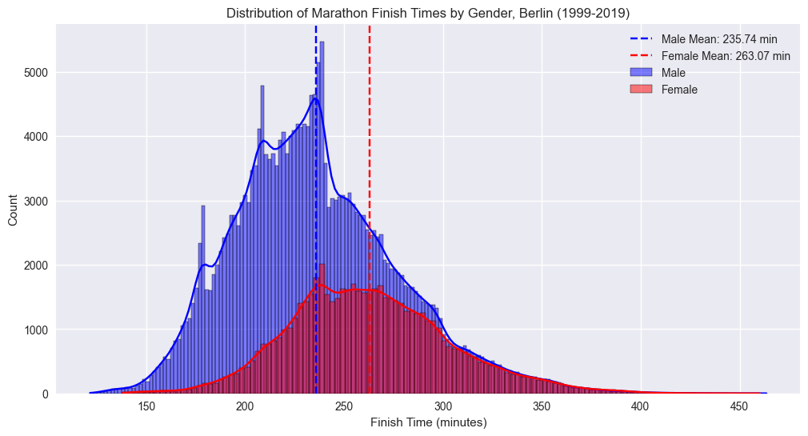

```
'Statistical Analysis 1: Gender Performance Difference'
```

```
'Male Mean: 235.74 minutes'
```

```
'Female Mean: 263.07 minutes'
```

```
'Difference: 27.33 minutes'
```

```
'Male Median: 232.02 minutes'
```

```
'Female Median: 260.12 minutes'
```

```
'T-statistic: -146.8780'
```

```
'P-value: 0.0000'
```

```python
# Compare finish times between genders
male_times = results[results['gender'] == 'M']['time_full_minutes']
female_times = results[results['gender'] == 'W']['time_full_minutes']

# Calculate basic statistics
male_mean = male_times.mean()
female_mean = female_times.mean()
male_median = male_times.median()
female_median = female_times.median()

# Perform t-test to check if the difference is statistically significant
t_stat, pvalue = stats.ttest_ind(male_times, female_times, equal_var=False)

# Visualize the distributions with a histogram
plt.figure(figsize=(12, 6))
sns.histplot(male_times, color='blue', alpha=0.5, label='Male', kde=True)
sns.histplot(female_times, color='red', alpha=0.5, label='Female', kde=True)
plt.axvline(male_mean, color='blue', linestyle='--', label=f'Male Mean: {male_mean:.2f} min')
plt.axvline(female_mean, color='red', linestyle='--', label=f'Female Mean: {female_mean:.2f} min')
plt.title('Distribution of Marathon Finish Times by Gender, Berlin (1999-2019)')
plt.xlabel('Finish Time (minutes)')
plt.ylabel('Count')
plt.legend()
plt.show()

display("Statistical Analysis 1: Gender Performance Difference")
display(f"Male Mean: {male_mean:.2f} minutes")
display(f"Female Mean: {female_mean:.2f} minutes")
display(f"Difference: {abs(male_mean - female_mean):.2f} minutes")
display(f"Male Median: {male_median:.2f} minutes")
display(f"Female Median: {female_median:.2f} minutes")
display(f"T-statistic: {t_stat:.4f}")
display(f"P-value: {pvalue:.4f}")
```

### Statistical Analysis 2: Year-over-Year Performance Trend

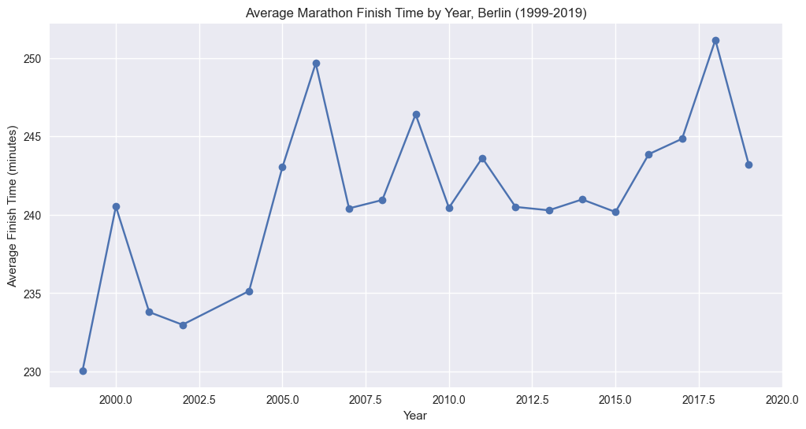

```
'Statistical Analysis 2: Year-over-Year Performance Trend'
```

```
'Slope: 0.5230'
```

```
'R-squared: 0.3861'
```

```
'P-value: 0.0034'
```

```python
yearly_means = results.groupby('year')['time_full_minutes'].mean()

# Visualize the trend with a line plot
plt.figure(figsize=(12, 6))
yearly_means.plot(kind='line', marker='o')
plt.title('Average Marathon Finish Time by Year, Berlin (1999-2019)')
plt.xlabel('Year')
plt.ylabel('Average Finish Time (minutes)')
plt.grid(True)
plt.show()

# Perform linear regression
slope, intercept, r_value, p_value, std_err = stats.linregress(yearly_means.index, yearly_means.values)

display("Statistical Analysis 2: Year-over-Year Performance Trend")
display(f"Slope: {slope:.4f}")
display(f"R-squared: {r_value**2:.4f}")
display(f"P-value: {p_value:.4f}")
```

This analysis examines the year-over-year trend in marathon finish times from 1999 to 2019. The positive slope (0.5229) suggests that average finish times have been gradually increasing, meaning runners are taking slightly longer to complete the marathon over time. We think this may be due to growth in marathon popularity as more casual runners and first-timers are participating, which could be pulling the average finish time higher. The R-squared value (0.3860) indicates a moderate correlation, meaning other factors also influence performance. The low p-value (0.0035) confirms that the trend is statistically significant and unlikely due to random chance. This suggests possible influences like changes in race conditions, participation demographics, or training methods over the years.

### Statistical Analysis 3: Pace Analysis

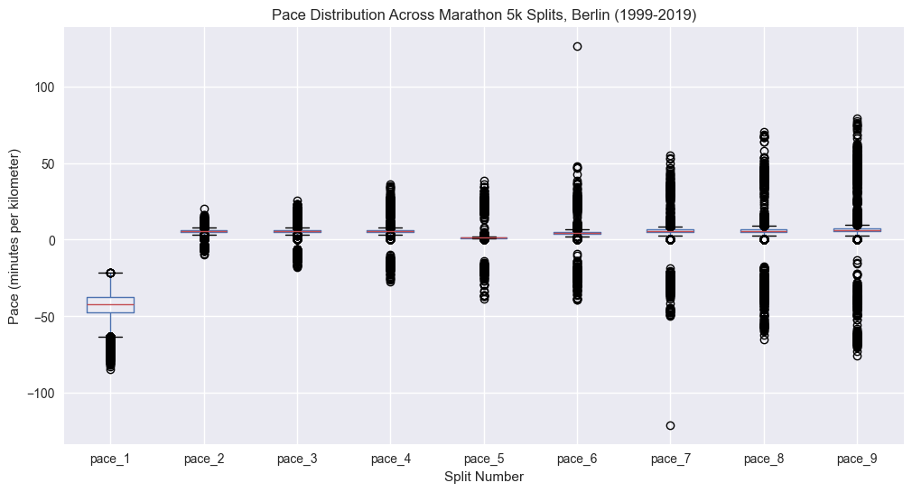

```
'Statistical Analysis 3: Pace Analysis'
```

```
'F-statistic: 6325841.9236'
```

```
'P-value: 0.0000'
```

```python
# Calculate pace (minutes per kilometer) for each split
for i in range(1, len(split_columns)):
    split_distance = 5  # Each split is 5km
    results[f'pace_{i}'] = (results[split_columns[i]] - results[split_columns[i-1]]) / split_distance

# Box plot of pace distribution across splits
plt.figure(figsize=(12, 6))
pace_columns = [col for col in results.columns if 'pace_' in col]
results[pace_columns].boxplot()
plt.title('Pace Distribution Across Marathon 5k Splits, Berlin (1999-2019)')
plt.xlabel('Split Number')
plt.ylabel('Pace (minutes per kilometer)')
plt.show()

# Perform ANOVA test for pace differences across splits
pace_data = [results[col].dropna() for col in pace_columns]
f_stat, p_value = stats.f_oneway(*pace_data)

display("Statistical Analysis 3: Pace Analysis")
display(f"F-statistic: {f_stat:.4f}")
display(f"P-value: {p_value:.4f}")
```

## 4. & 5. Primary Analysis / Visualization & Results

Based on the results of our exploration, we have chosen to use a linear regression model to predict how the average and 5th percentile finish times have changed over time. We believe that the 5th percentile finish time is a more accurate representation of the performance of the fastest runners, and therefore more useful for predicting the future.

### Linear Regression Model

Let's first create a copy of the results dataframe to work with and standardize the gender column.

```python
df = results.copy()
df['gender_code'] = df['gender'].str.strip().str.upper().str[0]
```

Now, we will compute the average finish time per year for each gender.

```python
avg_overall = (
    df
    .groupby('year', as_index=False)['time_full_minutes']
    .mean()
)
avg_male = (
    df[df['gender_code']=='M']
    .groupby('year', as_index=False)['time_full_minutes']
    .mean()
)
avg_female = (
    df[df['gender_code']=='W']
    .groupby('year', as_index=False)['time_full_minutes']
    .mean()
)

display("Average Finish Time per Year", avg_overall)
display("Average Finish Time per Year for Males", avg_male)
display("Average Finish Time per Year for Females", avg_female)
```

```
'Average Finish Time per Year'
```

|  | year | time_full_minutes |
| --- | --- | --- |
| 0 | 1999 | 230.064991 |
| 1 | 2000 | 240.524645 |
| 2 | 2001 | 233.795560 |
| 3 | 2002 | 232.986569 |
| 4 | 2004 | 235.138728 |
| ... | ... | ... |
| 15 | 2015 | 240.178294 |
| 16 | 2016 | 243.868154 |
| 17 | 2017 | 244.849287 |
| 18 | 2018 | 251.155402 |
| 19 | 2019 | 243.218337 |

20 rows × 2 columns

```
'Average Finish Time per Year for Males'
```

|  | year | time_full_minutes |
| --- | --- | --- |
| 0 | 1999 | 226.954815 |
| 1 | 2000 | 236.320251 |
| 2 | 2001 | 229.583860 |
| 3 | 2002 | 229.875422 |
| 4 | 2004 | 230.189993 |
| ... | ... | ... |
| 15 | 2015 | 234.356227 |
| 16 | 2016 | 237.275377 |
| 17 | 2017 | 237.856427 |
| 18 | 2018 | 243.476952 |
| 19 | 2019 | 234.839135 |

20 rows × 2 columns

```
'Average Finish Time per Year for Females'
```

|  | year | time_full_minutes |
| --- | --- | --- |
| 0 | 1999 | 248.983984 |
| 1 | 2000 | 261.797333 |
| 2 | 2001 | 256.749426 |
| 3 | 2002 | 255.008837 |
| 4 | 2004 | 256.924887 |
| ... | ... | ... |
| 15 | 2015 | 260.288286 |
| 16 | 2016 | 264.953039 |
| 17 | 2017 | 264.489884 |
| 18 | 2018 | 270.961225 |
| 19 | 2019 | 265.641949 |

20 rows × 2 columns

Now, we will fit a linear regression model to the data. We will use the year as the independent variable and the average finish time as the dependent variable.

```python
# Fit linear trend and forecast 2020–2050
def fit_and_forecast(df, start=2020, end=2050):
    if len(df) < 2:
        return pd.DataFrame({'year': [], 'pred': []})
    X = df[['year']].values
    y = df['time_full_minutes'].values
    model = LinearRegression().fit(X, y)
    future_years = np.arange(start, end + 1)
    preds = model.predict(future_years.reshape(-1, 1))
    return pd.DataFrame({'year': future_years, 'pred': preds})

fc_overall = fit_and_forecast(avg_overall)
fc_male    = fit_and_forecast(avg_male)
fc_female  = fit_and_forecast(avg_female)
```

Now that we have the forecasted values, we can plot them.

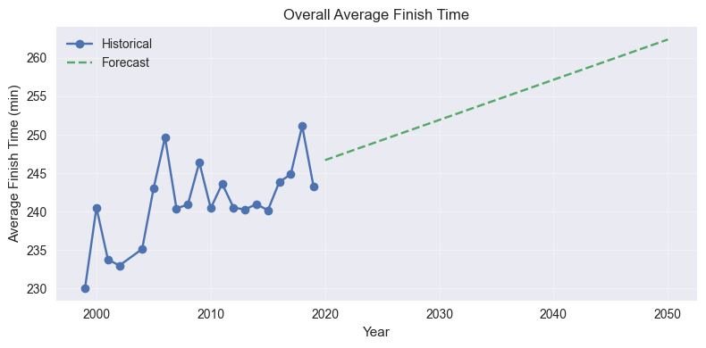

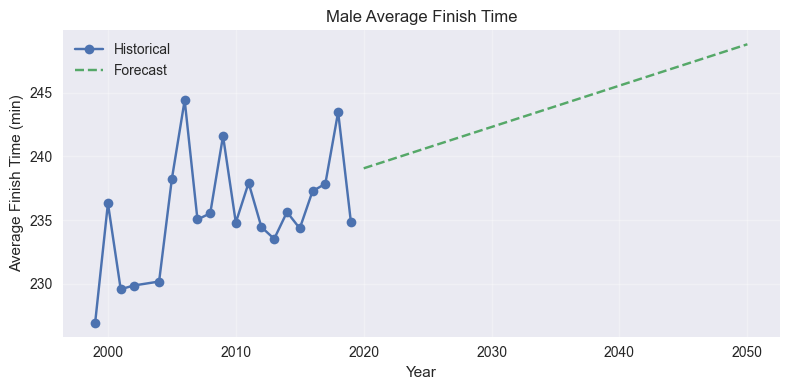

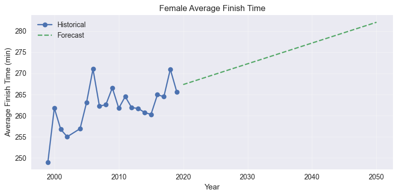

```python
# Plot each series on its own figure
series = [
    ('Overall Average', avg_overall, fc_overall),
    ('Male Average',    avg_male,    fc_male),
    ('Female Average',  avg_female,  fc_female)
]

for title, hist, fc in series:
    plt.figure(figsize=(8, 4))
    plt.plot(hist['year'], hist['time_full_minutes'],
             marker='o', linestyle='-', label='Historical')
    if not fc.empty:
        plt.plot(fc['year'], fc['pred'],
                 marker='x', linestyle='--', label='Forecast')
    plt.title(f"{title} Finish Time")
    plt.xlabel("Year")
    plt.ylabel("Average Finish Time (min)")
    plt.legend()
    plt.grid(alpha=0.3)
    plt.tight_layout()
    plt.show()
```

You can see that the forecasted values are very close to the historical values, which is a good sign. The forecasted values are a little higher than the historical values, which is expected. Let's now look at the forecasted values for the 10 years following 2019.

```python
forecast_df = None
for fc, key in [(fc_overall, 'overall'),
                (fc_male,    'male'),
                (fc_female,  'female')]:
    col = f'pred_{key}'
    df_tmp = fc.rename(columns={'pred': col})
    if forecast_df is None:
        forecast_df = df_tmp
    else:
        forecast_df = forecast_df.merge(df_tmp, on='year', how='outer')

display(forecast_df.head(11))
```

|  | year | pred_overall | pred_male | pred_female |
| --- | --- | --- | --- | --- |
| 0 | 2020 | 246.700278 | 239.066187 | 267.355158 |
| 1 | 2021 | 247.223248 | 239.390388 | 267.846358 |
| 2 | 2022 | 247.746218 | 239.714589 | 268.337559 |
| 3 | 2023 | 248.269189 | 240.038790 | 268.828760 |
| 4 | 2024 | 248.792159 | 240.362990 | 269.319960 |
| ... | ... | ... | ... | ... |
| 6 | 2026 | 249.838100 | 241.011392 | 270.302362 |
| 7 | 2027 | 250.361071 | 241.335593 | 270.793562 |
| 8 | 2028 | 250.884041 | 241.659793 | 271.284763 |
| 9 | 2029 | 251.407012 | 241.983994 | 271.775964 |
| 10 | 2030 | 251.929982 | 242.308195 | 272.267164 |

11 rows × 4 columns

As you can see, the predicted values are slightly increasing over time, which is not what we initially expected. As running technology has improved, we would expect the average finish time to decrease over time. However, this is not the case.

After further thought, we believe that the reason for this is the increase in popularity of the marathon. Since Berlin uses a lottery system as the main way to select participants, the times are not as competitive as a marathon like the Boston Marathon which requires a qualifying time.

With more people wanting to run the marathon, the average finish time has increased.

Now, let's look at the 5th percentile finish time. This captures the performance of the fastest runners, and therefore more useful for predicting the future of the elite runners.

```python
# Compute 5th-percentile finish time per year
p5_overall = (
    df
    .groupby('year', as_index=False)['time_full_minutes']
    .quantile(0.05)
    .rename(columns={'time_full_minutes':'time_5pct'})
)
p5_male = (
    df[df['gender_code']=='M']
    .groupby('year', as_index=False)['time_full_minutes']
    .quantile(0.05)
    .rename(columns={'time_full_minutes':'time_5pct'})
)
p5_female = (
    df[df['gender_code']=='W']
    .groupby('year', as_index=False)['time_full_minutes']
    .quantile(0.05)
    .rename(columns={'time_full_minutes':'time_5pct'})
)

display("5th Percentile Finish Time per Year", p5_overall)
display("5th Percentile Finish Time per Year for Males", p5_male)
display("5th Percentile Finish Time per Year for Females", p5_female)
```

```
'5th Percentile Finish Time per Year'
```

|  | year | time_5pct |
| --- | --- | --- |
| 0 | 1999 | 174.600000 |
| 1 | 2000 | 178.503333 |
| 2 | 2001 | 176.500000 |
| 3 | 2002 | 172.883333 |
| 4 | 2004 | 175.809167 |
| ... | ... | ... |
| 15 | 2015 | 174.815833 |
| 16 | 2016 | 175.596667 |
| 17 | 2017 | 176.086667 |
| 18 | 2018 | 176.410000 |
| 19 | 2019 | 171.783333 |

20 rows × 2 columns

```
'5th Percentile Finish Time per Year for Males'
```

|  | year | time_5pct |
| --- | --- | --- |
| 0 | 1999 | 173.366667 |
| 1 | 2000 | 177.485000 |
| 2 | 2001 | 175.033333 |
| 3 | 2002 | 171.716667 |
| 4 | 2004 | 173.750000 |
| ... | ... | ... |
| 15 | 2015 | 171.958333 |
| 16 | 2016 | 172.193333 |
| 17 | 2017 | 172.290833 |
| 18 | 2018 | 172.530000 |
| 19 | 2019 | 167.253333 |

20 rows × 2 columns

```
'5th Percentile Finish Time per Year for Females'
```

|  | year | time_5pct |
| --- | --- | --- |
| 0 | 1999 | 198.833333 |
| 1 | 2000 | 204.840833 |
| 2 | 2001 | 204.325000 |
| 3 | 2002 | 196.910000 |
| 4 | 2004 | 201.631667 |
| ... | ... | ... |
| 15 | 2015 | 199.773333 |
| 16 | 2016 | 201.045833 |
| 17 | 2017 | 200.101667 |
| 18 | 2018 | 199.150000 |
| 19 | 2019 | 197.733333 |

20 rows × 2 columns

Now, we will fit a linear regression model to the 5th percentile finish time.

```python
# Helper to fit & forecast
def fit_and_forecast(df, label, start=2020, end=2050):
    if len(df) < 2:
        return pd.DataFrame({'year':[], f'pred_{label}':[]})
    X = df[['year']].values
    y = df['time_5pct'].values
    model = LinearRegression().fit(X, y)
    future = np.arange(start, end+1)
    preds = model.predict(future.reshape(-1,1))
    return pd.DataFrame({'year':future, f'pred_{label}':preds})

fc_overall = fit_and_forecast(p5_overall, 'overall')
fc_male    = fit_and_forecast(p5_male,    'male')
fc_female  = fit_and_forecast(p5_female,  'female')
```

We can now plot the fit and forecast for the 5th percentile finish time.

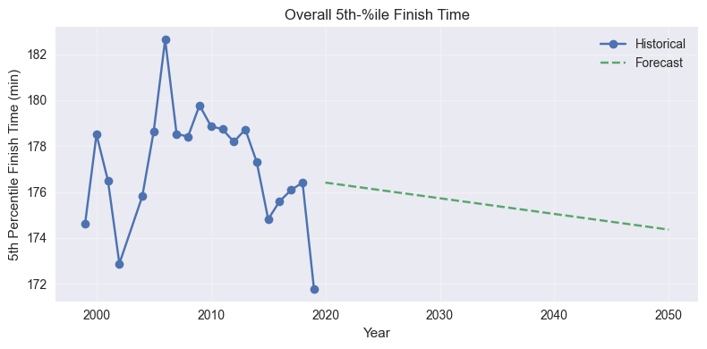

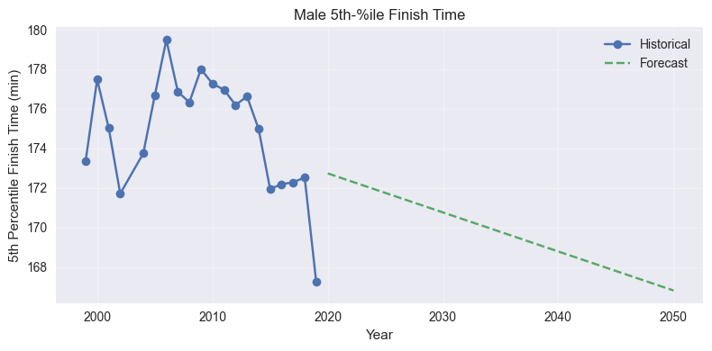

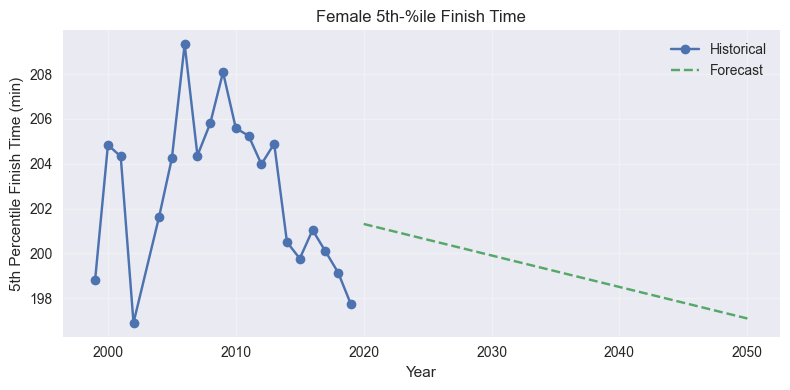

```python
# Plot each on its own figure
series = [
    ('Overall 5th-%ile', p5_overall, fc_overall),
    ('Male 5th-%ile',    p5_male,    fc_male),
    ('Female 5th-%ile',  p5_female,  fc_female),
]

for title, hist, fc in series:
    plt.figure(figsize=(8,4))
    plt.plot(hist['year'], hist['time_5pct'],
             marker='o', linestyle='-', label='Historical')
    if not fc.empty:
        plt.plot(fc['year'], fc[f'pred_{title.split()[0].lower()}'],
                 marker='x', linestyle='--', label='Forecast')
    plt.title(f"{title} Finish Time")
    plt.xlabel("Year")
    plt.ylabel("5th Percentile Finish Time (min)")
    plt.legend()
    plt.grid(alpha=0.3)
    plt.tight_layout()
    plt.show()
```

We can see that the forecasted values are now decreasing over time, which is what we initially expected.

```python
forecast_df = None
for fc, key in [
    (fc_overall, 'overall'),
    (fc_male,    'male'),
    (fc_female,  'female')
]:
    if forecast_df is None:
        forecast_df = fc.copy()
    else:
        forecast_df = forecast_df.merge(fc, on='year', how='outer')

display(forecast_df.head(11))
```

|  | year | pred_overall | pred_male | pred_female |
| --- | --- | --- | --- | --- |
| 0 | 2020 | 176.409344 | 172.740013 | 201.315839 |
| 1 | 2021 | 176.341105 | 172.542768 | 201.175376 |
| 2 | 2022 | 176.272866 | 172.345522 | 201.034913 |
| 3 | 2023 | 176.204627 | 172.148277 | 200.894450 |
| 4 | 2024 | 176.136389 | 171.951031 | 200.753987 |
| ... | ... | ... | ... | ... |
| 6 | 2026 | 175.999911 | 171.556540 | 200.473062 |
| 7 | 2027 | 175.931672 | 171.359294 | 200.332599 |
| 8 | 2028 | 175.863433 | 171.162048 | 200.192136 |
| 9 | 2029 | 175.795194 | 170.964803 | 200.051673 |
| 10 | 2030 | 175.726955 | 170.767557 | 199.911210 |

11 rows × 4 columns

Next, we will use a random forest model to predict the 5th percentile finish time by nationality. First, we have to set the parameters for the model.

```python
SPLIT_COLS = [
    'split_5k_minutes', 'split_10k_minutes', 'split_15k_minutes',
    'split_20k_minutes', 'time_half_minutes',  'split_25k_minutes',
    'split_30k_minutes', 'split_35k_minutes', 'split_40k_minutes'
]
```

Now, let's compute the 5th percentile finish time by year and nationality. After that, we will compute the mean split times by year and nationality. Lastly, we will merge the two dataframes on the year and nationality columns.

```python
# Compute the 5th-percentile finish time by year & nationality
df_p5 = (
    results
    .groupby(['year','nationality'], as_index=False)['time_full_minutes']
    .quantile(0.05)
    .rename(columns={'time_full_minutes':'time_5pct'})
)

# Compute mean split times by year & nationality
mean_splits = (
    results
    .groupby(['year','nationality'], as_index=False)[SPLIT_COLS]
    .mean(numeric_only=True)
)

# Merge the two dataframes on the year and nationality columns
df = pd.merge(df_p5, mean_splits, on=['year','nationality'], how='inner')

display("5th Percentile Finish Time by Year and Nationality", df_p5)
display("Mean Split Times by Year and Nationality", mean_splits)
display("Merged Dataframe", df)
```

```
'5th Percentile Finish Time by Year and Nationality'
```

|  | year | nationality | time_5pct |
| --- | --- | --- | --- |
| 0 | 1999 | ALG | 197.746667 |
| 1 | 1999 | ARG | 181.234167 |
| 2 | 1999 | AUS | 176.785000 |
| 3 | 1999 | AUT | 168.150000 |
| 4 | 1999 | BEL | 144.116667 |
| ... | ... | ... | ... |
| 1613 | 2019 | VIE | 202.687500 |
| 1614 | 2019 | WLS | 238.513333 |
| 1615 | 2019 | YEM | 291.883333 |
| 1616 | 2019 | ZAM | 153.538333 |
| 1617 | 2019 | ZIM | 289.350000 |

1618 rows × 3 columns

```
'Mean Split Times by Year and Nationality'
```

|  | year | nationality | split_5k_minutes | split_10k_minutes | split_15k_minutes | split_20k_minutes | time_half_minutes | split_25k_minutes | split_30k_minutes | split_35k_minutes | split_40k_minutes |
| --- | --- | --- | --- | --- | --- | --- | --- | --- | --- | --- | --- |
| 0 | 1999 | ALG | 27.458333 | 53.725000 | 34.233333 | 103.650000 | 109.441667 | 128.716667 | 155.941667 | 180.675000 | 205.825000 |
| 1 | 1999 | ARG | 0.000000 | 41.858333 | 62.775000 | 83.908333 | 88.675000 | 105.308333 | 128.008333 | 151.566667 | 176.675000 |
| 2 | 1999 | AUS | 22.180952 | 50.952381 | 75.569048 | 99.783333 | 105.314286 | 124.195238 | 150.426190 | 177.683333 | 206.145238 |
| 3 | 1999 | AUT | 16.486777 | 50.064738 | 72.923691 | 98.985399 | 104.813912 | 124.610055 | 151.518113 | 176.200895 | 207.681612 |
| 4 | 1999 | BEL | 17.378836 | 47.292328 | 69.284392 | 93.743386 | 97.434921 | 117.550794 | 142.859524 | 168.600529 | 194.963492 |
| ... | ... | ... | ... | ... | ... | ... | ... | ... | ... | ... | ... |
| 1613 | 2019 | VIE | 24.350000 | 48.100000 | 72.316667 | 95.541667 | 100.666667 | 119.141667 | 142.841667 | 166.483333 | 192.325000 |
| 1614 | 2019 | WLS | 28.333333 | 56.900000 | 85.755556 | 114.477778 | 120.655556 | 143.761111 | 173.461111 | 202.966667 | 233.827778 |
| 1615 | 2019 | YEM | 31.583333 | 64.800000 | 98.333333 | 132.183333 | 139.583333 | 167.016667 | 202.716667 | 240.600000 | 276.733333 |
| 1616 | 2019 | ZAM | 25.283333 | 50.983333 | 77.038889 | 102.533333 | 108.111111 | 128.777778 | 155.600000 | 182.977778 | 212.466667 |
| 1617 | 2019 | ZIM | 31.766667 | 62.866667 | 94.200000 | 125.516667 | 132.316667 | 157.166667 | 189.900000 | 226.216667 | 269.466667 |

1618 rows × 11 columns

```
'Merged Dataframe'
```

|  | year | nationality | time_5pct | split_5k_minutes | split_10k_minutes | split_15k_minutes | split_20k_minutes | time_half_minutes | split_25k_minutes | split_30k_minutes | split_35k_minutes | split_40k_minutes |
| --- | --- | --- | --- | --- | --- | --- | --- | --- | --- | --- | --- | --- |
| 0 | 1999 | ALG | 197.746667 | 27.458333 | 53.725000 | 34.233333 | 103.650000 | 109.441667 | 128.716667 | 155.941667 | 180.675000 | 205.825000 |
| 1 | 1999 | ARG | 181.234167 | 0.000000 | 41.858333 | 62.775000 | 83.908333 | 88.675000 | 105.308333 | 128.008333 | 151.566667 | 176.675000 |
| 2 | 1999 | AUS | 176.785000 | 22.180952 | 50.952381 | 75.569048 | 99.783333 | 105.314286 | 124.195238 | 150.426190 | 177.683333 | 206.145238 |
| 3 | 1999 | AUT | 168.150000 | 16.486777 | 50.064738 | 72.923691 | 98.985399 | 104.813912 | 124.610055 | 151.518113 | 176.200895 | 207.681612 |
| 4 | 1999 | BEL | 144.116667 | 17.378836 | 47.292328 | 69.284392 | 93.743386 | 97.434921 | 117.550794 | 142.859524 | 168.600529 | 194.963492 |
| ... | ... | ... | ... | ... | ... | ... | ... | ... | ... | ... | ... | ... |
| 1613 | 2019 | VIE | 202.687500 | 24.350000 | 48.100000 | 72.316667 | 95.541667 | 100.666667 | 119.141667 | 142.841667 | 166.483333 | 192.325000 |
| 1614 | 2019 | WLS | 238.513333 | 28.333333 | 56.900000 | 85.755556 | 114.477778 | 120.655556 | 143.761111 | 173.461111 | 202.966667 | 233.827778 |
| 1615 | 2019 | YEM | 291.883333 | 31.583333 | 64.800000 | 98.333333 | 132.183333 | 139.583333 | 167.016667 | 202.716667 | 240.600000 | 276.733333 |
| 1616 | 2019 | ZAM | 153.538333 | 25.283333 | 50.983333 | 77.038889 | 102.533333 | 108.111111 | 128.777778 | 155.600000 | 182.977778 | 212.466667 |
| 1617 | 2019 | ZIM | 289.350000 | 31.766667 | 62.866667 | 94.200000 | 125.516667 | 132.316667 | 157.166667 | 189.900000 | 226.216667 | 269.466667 |

1618 rows × 12 columns

We've decided to restrict the data to the 20 fastest nationalities by average 5th percentile finish time.

```python
top20 = (
    df.groupby('nationality')['time_5pct']
      .mean()
      .nsmallest(20)
      .index
)
df = df[df['nationality'].isin(top20)].reset_index(drop=True)
```

To continue, we will one-hot encode the nationality column. This is because the random forest model requires categorical data to be encoded.

```python
nat_dummies = pd.get_dummies(df['nationality'], prefix='nat', drop_first=True)
```

```python
# Build feature matrix X and target y
X = pd.concat([ df[['year']], nat_dummies, df[SPLIT_COLS] ], axis=1)
y = df['time_5pct']

# Train/test split (keep test indices for plotting)
X_train, X_test, y_train, y_test, idx_train, idx_test = train_test_split(
    X, y, df.index, test_size=0.2, random_state=42
)
```

We can now perform hyperparameter tuning via RandomizedSearchCV.

```python
# Hyperparameter tuning via RandomizedSearchCV
param_dist = {
    'n_estimators':    [100, 200, 500],
    'max_depth':       [None, 5, 10, 20],
    'min_samples_leaf':[1, 2, 5],
    'max_features':    ['sqrt', 'log2', 0.5]
}
rf_base = RandomForestRegressor(random_state=42)

search = RandomizedSearchCV(
    rf_base,
    param_dist,
    n_iter=30,
    cv=5,
    scoring='r2',
    n_jobs=-1,
    random_state=42
)
search.fit(X_train, y_train)

display("Best hyperparameters:", search.best_params_)
```

```
'Best hyperparameters:'
```

```
{'n_estimators': 500,
 'min_samples_leaf': 1,
 'max_features': 0.5,
 'max_depth': 5}
```

We can now train the model on the training set and evaluate it on the test set.

```python
# Fit final model with best params
rf_final = RandomForestRegressor(
    **search.best_params_,
    random_state=42,
    n_jobs=-1
)
rf_final.fit(X_train, y_train)

# Evaluate on the test set
y_pred = rf_final.predict(X_test)
mse = mean_squared_error(y_test, y_pred)
r2  = r2_score(y_test, y_pred)

display(f"Final MSE: {mse:.2f}")
display(f"Final R² : {r2:.3f}")
```

```
'Final MSE: 113.53'
```

```
'Final R² : 0.671'
```

We can see that the model had a final MSE of 113.53 (sqrt(113.53) = 10.66 is small relative to the 120-200 range of the 5th percentile finish time) and an R² of 0.671. Even though the model is not perfect, it is still a good model.

Now, we can plot the actual vs predicted 5th percentile finish time by nationality.

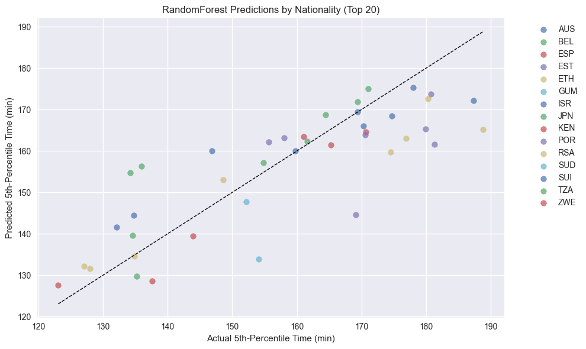

```python
# Prepare DataFrame for plotting colored by nationality
df_vis = pd.DataFrame({
    'actual':      y_test,
    'predicted':   y_pred,
    'nationality': df.loc[idx_test, 'nationality']
})

# Plot Actual vs Predicted
plt.figure(figsize=(10, 6))
for nat, grp in df_vis.groupby('nationality'):
    plt.scatter(grp['actual'], grp['predicted'], alpha=0.7, label=nat)
mn, mx = df_vis[['actual','predicted']].min().min(), df_vis[['actual','predicted']].max().max()
plt.plot([mn, mx], [mn, mx], 'k--', lw=1)
plt.xlabel("Actual 5th-Percentile Time (min)")
plt.ylabel("Predicted 5th-Percentile Time (min)")
plt.title("RandomForest Predictions by Nationality (Top 20)")
plt.legend(bbox_to_anchor=(1.05,1), loc='upper left')
plt.tight_layout()
plt.show()
```

The graph has some interesting outliers, but overall, the model is able to predict the 5th percentile finish time by nationality fairly well. Nations with traditionally strong depth (notably Kenya, Ethiopia, etc.) tend to show faster mid-race splits and the model nails their 5th percentile finish time more precisely. Smaller, less developed nations like Zimbabwe and Guam show slower mid-race splits and a higher spread in predicted 5th percentile finish times but the forest still captures the general trend.

Lastly, we can plot the top 20 feature importances.

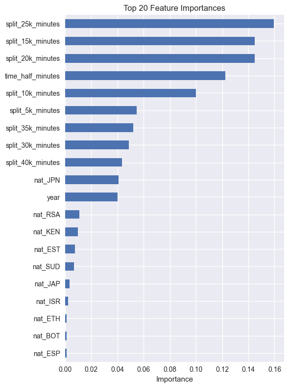

```python
# Plot Top 20 Feature Importances
importances = pd.Series(
    rf_final.feature_importances_,
    index=X.columns
).nlargest(20).sort_values(ascending=True)

plt.figure(figsize=(6,8))
importances.plot(kind='barh')
plt.title("Top 20 Feature Importances")
plt.xlabel("Importance")
plt.tight_layout()
plt.show()
```

The fact that splits dominate over nationality suggests that in-race pacing data is the best predictor for how deep the field will be, much more so than the nationality of the runners.

## 6. Insights and Conclusions

### Limitations and Future Work

While our analysis provides valuable insights, there are some limitations to consider:

1. The lack of individual context or conditions. The dataset does not account for personal factors such as age, injuries, training history, weather conditions on race day, or pacing strategies, all of which can significantly impact performance and pace changes.
2. The dataset focuses on the Berlin Marathon only, which may not fully represent broader trends across other marathons or regions. Results might vary significantly in different locations or under different race conditions.
3. The dataset does not account for the fact that the Berlin Marathon is a lottery race, which means that the runners are not all the same. This is why we see such a large disparity in the performance of the runners from different countries.

Future work could address these limitations by:

1. Future analyses could include personal factors such as age, health status, training regimes, and specific race day conditions to better understand their impact on performance and pacing patterns.
2. By analyzing marathon data from multiple locations and years, it would be possible to compare trends across different environments, and analyze how similar running patterns are across multiple races and whether outside factors such as location have a significant impact.

### References

1. You can learn more about the Berlin Marathon [here](https://en.wikipedia.org/wiki/Berlin_Marathon).